# Tunnuste tüübid ja andmetüübid, tunnuse jaotus ja kirjeldav statistika

Indrek Soidla

2023-09-22

## Tunnuste tüübid

Eelmine kord tegelesime juba andmetega ja erinevate tunnuste kokkuvõtlike näitajate (nt aritmeetilise keskmise) arvutamisega, aga ei rääkinud konkreetsemalt tunnuste tüüpidest. (Tuletame meelde, et andmestikus on tunnused reeglina veergudes, ühe veeru andmed on üks tunnus; ridades on indiviidid (küsitlusuuringu puhul enamasti inimindiviidid, aga võivad olla ka nt riigid, nagu esimese teema andmestikes), tunnuse väärtustega kirjeldame neid indiviide.) Tunnuste tüüpides orienteerumine on väga oluline, et osata hiljem andmeanalüüsil valida sobiv analüüsimeetod. Enamlevinud tüpoloogia järgi võivad tunnused olla nelja erinevat tüüpi.

- Kategoriaalsed tunnused
  - Nominaaltunnus – tunnuse väärtused annavad vaid objekti kirjelduse, aga ei ütle midagi kirjeldatud omaduse intensiivsuse või suuruse kohta (nt sugu, rahvus, perekonnaseis)
  - Järjestustunnus – tunnuse väärtused on intensiivsuse põhjal järjestatavad, kuid skaalapunktide vahed ei pruugi olla võrdsed (nt haridustase, meeldivuse ja rahulolu hinnangud)
- Arvulised tunnused
  - Diskreetne tunnus – tunnuse väärtusteks saavad olla ainult täisarvulised loendatavad vastusevariandid (nt laste arv peres)
  - Pidev tunnus – tunnuse väärtusteks võivad olla kõik punktid tunnuse skaalal, sh murdarvud (nt pikkus, kaal, vanus, sissetulek)

Arvulised tunnused erinevad järjestustunnustest selle poolest, et väärtuste vahed on võrreldavad, nt 1 ja 2 erinevus on sama suur kui 2 ja 3 erinevus või 4,4 ja 5,4 erinevus. Järjestustunnuse puhul väärtuste vahed võrreldavad ei ole või ei saa me selles kindlad olla, nt võivad skaalapunktid olla küll kirjeldatud järjestikuste täisarvudega, aga nende tähenduste erinevused ei pruugi olla võrdsed (skaalapunktide sisuline erinevus ei lange kokku arvuliste erinevustega). Selline on näiteks järgmine küsitlusuuringutes kasutatav skaala, kus küsitakse, kuivõrd vastaja nõustub mingi talle esitatava väitega.

- 1 Täiesti nõus
- 2 Nõus
- 3 Ei ole poolt ega vastu
- 4 Ei ole nõus
- 5 Ei ole üldse nõus

Antud juhul ei saa me olla kindlad, et kõik vastajad tõlgendavad skaalapunktide sisulisi vahesid võrdsetena, st ei saa eeldada, et vastajate jaoks skaalapunktid “Täiesti nõus” ja “Nõus” on teineteisest sama kaugel kui “Nõus” ja “Ei ole poolt ega vastu” (seda enam, et vastajale võidakse esitada ainult sõnalised vastusevariandid, mitte nendega seostuvad koodid, mis on eelkõige andmetöötluse, mitte küsitlemise jaoks). Seega on tegu järjestustunnusega, mis tähendab, et sellise tunnuse puhul pole kohane kasutada arvulist tunnusetüüpi eeldavaid analüüsimeetodeid, nt arvutada aritmeetilist keskmist. Tehniliselt on muidugi võimalik seda teha, aga tulemus ei pruugi olla täpne. Kuivõrd rangelt järjestus- ja arvulistel tunnustel vahet tehakse, sõltub konkreetsest olukorrast (kui suurt täpsust meil analüüsis vaja on) ja muidugi ka ainevaldkonnast, nt psühholoogias see eristus niivõrd range ei ole. Lähtume antud kursuses siiski sotsioloogias pigem levinud arusaamadest, mille järgi nt eelnevalt kirjeldatud skaalaga tunnus on järjestustunnus ja arvulist tunnusetüüpi eeldavaid meetodeid pole sel juhul kohane kasutada. Millised on mingi analüüsimeetodi eeldused, õpime iga meetodi juures eraldi.

NB! Eelnevast võite juba järeldada, et see, mis tüüpi on tunnus, ei sõltu sellest, millisel kujul on andmestikus tunnuse väärtused esitatud - nt on küsitlusuuringute andmestikes tavaline, et tunnustel on arvulised koodid ja nendel koodidel kirjeldused ehk märgendid *(labels)*. Tunnuse tüübi kindlakstegemisel tuleks sellisel juhul eelkõige lähtuda märgendite tähendusest ja sellest, mida tunnus sisuliselt mõõdab. Näiteks soo tunnuse väärtused võivad andmestikus olla 1 ja 2, sealjuures ühega tähistatakse näiteks naisi ja kahega mehi (võib olla ka vastupidi) - see ei tähenda, et tegu oleks arvulise tunnusega. Tegu on nominaaltunnusega, selle määrab tunnuse iseloom ehk mida tunnusega mõõdetakse - mees ja naine ei ole tunnuse iseloomu poolest kuidagi järjestatavad (mees ei ole kuidagi rohkem sugu kui naine ega vastupidi). Kuigi mehed võivad olla näiteks enamasti pikemad kui naised või kaaluda rohkem ja selliste näitajate alusel saab ühes kogumis olevaid mehi ja naisi järjestada, oleks need juba eraldi tunnused (pikkus ja kaal).

## Andmetüübid R-s

R-s on kasutusel mõnevõrra erinevad andmetüübid, oluline on orienteeruda ka neis. R-s on *andme*tüübid ehk nende tüüpidega on kirjeldatavad üksikud väärtused, nende alusel saab omakorda kirjeldada ka tunnuseid ehk andmestiku veerge, sest ühe veeru andmed saavad olla ainult ühte tüüpi. Näiteks võib mingi väärtus olla arvuline *(numeric)*, olles sealjuures kas pidev (*double*, nt 1.453 või 200.01)

```r
typeof(1.453)
```

```
## [1] "double"
```

või diskreetne ehk täisarvuline (*integer*, nt 1 või 200, R-s tähistataks neid pidevat tüüpi väärtusest eristamiseks 1L ja 200L).

```r
typeof(1L)
```

```
## [1] "integer"
```

Väärtus võib olla veel tekstiline (*character*, nt “puu” või “lill”)

```r
typeof("puu")
```

```
## [1] "character"
```

või loogiline (*logical*, saab olla ainult kas TRUE või FALSE).

```r
typeof(TRUE)
```

```
## [1] "logical"
```

Eelmisel korral tegelesime andmestike ehk *data frame*’idega, kus ridades on indiviidid ja veergudes tunnused, sealjuures on kõik read ühepikkused ja veerud ühepikkused (st igas veerus on nii palju väärtuseid kui on indiviide ja igas reas nii palju väärtuseid kui on tunnuseid). Ühe veeru ehk tunnuse väärtused saavad olla vaid ühte tüüpi, seega

- tunnus, mille kõik väärtused on pidevat tüüpi, on R-s *double*-tüüpi ehk pidev tunnus;
- tunnus, mille kõik väärtused on *integer*-tüüpi, on ka ise *integer*-tüüpi ehk diskreetne;
- tunnus, mille väärtused on tekstilised *character*-tüüpi, on ka ise *character*-tüüpi tunnus; *character*-tüüpi tunnus on alguses vaadatud neljase tunnuste tüpoloogia järgi alati kategoriaalne tunnus.

### *Data frame*-id ja vektorid

```r
arvud <- c(19, 9, 15, 4)
```

Nagu tunnus *data frame*-s, saab ka vektor ehk vektoris olevad andmed olla ainult ühte tüüpi, antud vektor on pidevat tüüpi (selles on küll ainult täisarvud, aga me ei ole R-le ette andnud, et neid arve tuleb tingimata täisarvulistena käsitleda, ei ole defineerinud `arvud <- c(19L, 9L, 15L)`):

```r
typeof(arvud)
```

```
## [1] "double"
```

Vektorist saame väärtusi välja võtta nurksulgude abil, sisestades nurksulgudesse väärtuse järjekorranumbri. Näiteks kui soovime teada, kui suur on vektoris arvud teisel kohal olev arv, siis saame kirjutada:

```r
arvud[2]
```

```
## [1] 9
```

Samuti saame teha ka tehteid:

```r
arvud[2] + arvud[3]
```

```
## [1] 24
```

Põhimõtteliselt võib *data frame*-i käsitleda kui ühepikkuste vektorite kogu, ühepikkused vektorid saamegi liita kokku *data frame*-ks. Anname andmestikus tunnustele ka teistsugused nimed kui eelnevates näidetes vektoritel, et oleks edaspidistes näidetes selgem, millal teeme tehteid eraldiseisvate vektoritega, millal tunnustega andmestikust.

```r
taimed <- c("puu", "põõsas", "lill", "lill")
df <- data.frame(arvud, taimed)
names(df) <- c("numbers", "plants")
df
```

```
##   numbers plants
## 1      19    puu
## 2       9 põõsas
## 3      15   lill
## 4       4   lill
```

```r
typeof(df$numbers)
```

```
## [1] "double"
```

```r
typeof(df$plants)
```

```
## [1] "character"
```

Üks põhilisi veateate allikaid on see, kui meil jääb kahe silma vahele, millist tüüpi andmehulka funktsioon eeldab. Näiteks, kas funktsioon eeldab, et andmehulk, millega ta peab midagi tegema ja mille talle (enamasti esimese argumendiga) ette anname, on vektor või *data frame*. Osad `dplyr`-i ja muude `tidyverse`-i hulka kuuluvate pakettide funktsioonid eeldavad, et anname *eraldi* argumendiga ette *data frame*-i nime, mõned muud funktsioonid jällegi eeldavad vektorit ehk konkreetset veergu andmestikust. Võrdleme, kuidas käituvad *dplyr*-i funktsioon *select* ja paketi *base* (see pakett laetakse sisse automaatselt R-i käivitamisega) funktsioon *mean*.

```r
library(dplyr)
select(df, numbers) # anname ette eraldi argumentidena andmestiku ja tunnuse sellest andmestikust
```

```
##   numbers
## 1      19
## 2       9
## 3      15
## 4       4
```

```r
mean(arvud) # anname ette eraldiseisva vektori
```

```
## [1] 11.75
```

```r
mean(df$numbers) # funktsioon töötab ka, kui defineerida ühes argumendis koos andmestik ja tunnus
```

```
## [1] 11.75
```

Järgnevad käsud seevastu võimalikud poleks, annaksid veateate:

```r
select(df$numbers) # antakse ette tunnus andmestikust ehk sisuliselt üks vektor - ei tööta
# select tahab esmalt eraldi argumendina andmestikku ja seejärel eraldi argumendina tunnust sellest andmestikust
mean(df) # antakse ette kogu andmestik, funktsioon ei oska kogu andmestikuga midagi peale hakata, eeldab vektorit
```

Seda, kas mingi andmeobjekti puhul on tegu *data frame*-iga, saame teada funktsiooni `class` abil:

```r
class(df)
```

```
## [1] "data.frame"
```

### Sisuliselt erinevat tüüpi väärtused vektoris/tunnuses

Nii vektorite kui *data frame*-i tunnuste puhul kehtib reegel, et kui vektoris või tunnuses esineb väärtuseid, mis on sisuliselt erinevat tüüpi, käsitleb R neid kõiki automaatselt madalamat tüüpi väärtustena, nt:

```r
vektor <- c(2, 35, "6", "kuus", "ohoo")
typeof(vektor)
```

```
## [1] "character"
```

Kuna antud vektoris on peale väärtuste 2 ja 35 ka tekstilised väärtused “6”, “kuus” ja “ohoo”, käsitleb R väärtusi 2 ja 35 tekstiliste väärtustena, mitte arvudena. Seega pole ka võimalik nt tehe

```r
vektor[1] + vektor[2]
```

Andmeid mingist failist sisse lugedes tasub seega veateadete puhul ka kontrollida, mis tüüpi analüüsis kasutatavad tunnused R-i mõistes on. Näiteks võib juhtuda, et tunnuses on arvud, aga andmete sisselugemisel muutuvad nad andmeformaadi ümberkonverteerimisel tekstiks (*character*-tüüpi andmeteks). Andmeid saab põhimõtteliselt ühest tüübist teise konverteerida, aga see eeldab, et see on põhimõtteliselt võimalik - arve, mis on defineeritud tekstina (nt “6”), on võimalik arvuliseks muuta, teksti arvudeks muuta mitte (R ei saa aru, et nt tekst “kuus” peaks omama tähendust 6).

```r
vektor[1:2] # vektori esimesed kaks liiget esitatakse tekstiliste andmetena (jutumärkides), sest vektori ülejäänud liikmed on character-tüüpi ja seega kõiki vektori liikmeid käsitleb R character-ina
```

```
## [1] "2"  "35"
```

```r
as.numeric(vektor[1:3]) # vektori kolm esimest liiget esitatakse arvudena, sest funktsiooniga as.numeric konverteeritakse nad väljundi jaoks arvudeks (NB! ainult väljundi jaoks, sest konverteerimise tulemust objektile vektor siin tagasi ei omistata)
```

```
## [1]  2 35  6
```

```r
library(magrittr) # laeme sisse paketi magrittr, et kasutada pipe'i
```

```r
as.numeric(vektor[1:3]) %>% sum() # vektori esimest kolme liiget saab pärast konverteerimist käsitleda arvudena, seega on võimalik arvutada nende summa
```

```
## [1] 43
```

Kui üritame konverteerida arvuliseks kogu vektori, saame kahe viimase liikme väärtusteks andmelüngad, sest neid konverteerida ei õnnestu. Sellisel juhul on võimalik kogu vektori summa arvutada, kui täpsustame, et andmelüngad jäetakse arvutusest välja.

```r
as.numeric(vektor)
```

```
## [1]  2 35  6 NA NA
```

```r
as.numeric(vektor) %>% sum(na.rm = TRUE)
```

```
## [1] 43
```

### Järjestustunnus R-s

Nägime eelnevalt, et R-s on olemas arvuliste tunnuste tüübid ja et R-i *character*-tüüpi tunnus on kategoriaalne tunnus. Aga kas R-s on ka eraldi järjestustunnuste tüüp? Eelnevalt vaadatud nelja R-i andmetüübi seas *(double, integer, character, logical)* sellist otseselt ei ole, aga tunnus on võimalik eraldi defineerida kategoriaalsena ehk *factor*ina (nimetagem seda eestipäraselt faktoriks) ehk anda talle klass *factor*. Faktori väärtustel on kirjeldused ehk *labels* ehk tasemed ehk *levels*. Tasemeid saab järjestada, seega saab faktor olla järjestustunnus.

Näiteks lisame andmestikku `df` tunnuse `korgus` ja lisame sellele väärtused vastavalt tunnuse `taimed` väärtustele (puu on kõige kõrgem, lill tavaliselt madalaim taim).

```r
korgus <- c("kõrge", "madal", "kõige madalam", "kõige madalam")
df <- data.frame(df, korgus)
```

Tegu on tekstilise tunnusega:

```r
typeof(df$korgus)
```

```
## [1] "character"
```

Muudame tunnuse faktoriks:

```r
df$korgus <- as.factor(df$korgus)
```

Kuna faktor ei ole üks R-i n-ö sisse ehitatud neljast põhilisest andmetüübist, siis tuvastame selle funktsiooniga `class`:

```r
class(df$korgus)
```

```
## [1] "factor"
```

Me ei defineerinud tekstilise faktori kategooriate ehk *level*-ite järjestust, seetõttu järjestatakse kategooriad mitte nende sisu järgi (kõrge, madal, kõige madalam), vaid tähestikulises järjekorras nagu näha sagedusjaotuse tabelist:

```r
library(summarytools)
freq(df$korgus)
```

```
## Frequencies
## df$korgus
## Type: Factor
##
##                       Freq   % Valid   % Valid Cum.   % Total   % Total Cum.
## ------------------- ------ --------- -------------- --------- --------------
##       kõige madalam      2     50.00          50.00     50.00          50.00
##               kõrge      1     25.00          75.00     25.00          75.00
##               madal      1     25.00         100.00     25.00         100.00
##                <NA>      0                               0.00         100.00
##               Total      4    100.00         100.00    100.00         100.00
```

Et juba olemasoleva faktori väärtusi järjestada väärtuste sisulise tähenduse järgi, saab kasutada nt funktsiooni `fct_relevel` paketist `forcats` (võimalik, et paketi sisselaadimiseks peate selle eelnevalt ka installeerima käsuga `install.packages("forcats")`:

```r
library(forcats)
df$korgus <- fct_relevel(df$korgus, "kõrge", "madal", "kõige madalam")
freq(df$korgus)
```

```
## Frequencies
## df$korgus
## Type: Factor
##
##                       Freq   % Valid   % Valid Cum.   % Total   % Total Cum.
## ------------------- ------ --------- -------------- --------- --------------
##               kõrge      1     25.00          25.00     25.00          25.00
##               madal      1     25.00          50.00     25.00          50.00
##       kõige madalam      2     50.00         100.00     50.00         100.00
##                <NA>      0                               0.00         100.00
##               Total      4    100.00         100.00    100.00         100.00
```

Erinevaid andmehulkade tüüpe on R-s veel, aga nendega me tegelema vähe, kui üldse. Olgu siin ära mainitud ainult maatriks ehk *matrix*, mis erineb *data frame*-ist selle poolest, et veergudes peavad olema andmed sama tüüpi (nt saavad maatriksis kõik andmed olla arvulised), ja list, mis võimaldab ühedimensionaalsesse andmehulka lisada erinevat andmetüüpi väärtusi nii, et iga väärtus säilitab oma andmetüübi (erinevalt vektorist ja *data frame*-i tunnusest).

Nagu öeldud, andme- ja tunnuste tüüpides on oluline orienteeruda, sest erinevad analüüsimeetodid eeldavad erinevat tüüpi andmeid. Näiteks R-s saate veateate juhul, kui üritate faktortüüpi tunnusest keskmist arvutada. Antud hetkeks pole me erinevaid analüüsimeetodeid praktiliselt veel õppinudki, seetõttu on ok, et tunnuste tüübid ja nende eripärad võivad antud hetkel jääda veel abstraktseks. Praegu on oluline omada tunnuste tüüpidest mingitki ülevaadet, et kui need mõisted kuskil hiljem ette tulevad, oleks mingi taust olemas ja kuskil tagumises ajusagaras n-ö tugipunkt, millega edasisi teadmisi seostada. Tunnuste tüüpidega puutume edaspidi kindlasti korduvalt kokku.

## Esmane info andmestiku kohta

Vaatame täna lähemalt, kuidas R-s saada ülevaade kategoriaalsete tunnuste jaotustest. Hästi sobivad selleks mingi küsitlusuuringu nagu Euroopa Sotsiaaluuringu (ESS) andmed. Tegu on ühe kvaliteetseima rahvusvahelise küsitlusuuringuga, mida viiakse läbi iga kahe aasta tagant enamikus Euroopa riikides ja mille andmed on veebis vabalt kättesaadavad. Andmed on esinduslikud uuringus osalevate riikide elanikkonna suhtes (täpsemalt, vähemalt 15-aastaste alaliste elanike suhtes). Veebist on ESS-i andmed allalaetavad näiteks SPSS-i ehk .sav formaadis, sellises formaadis andmestiku R-i laadimiseks saab kasutada funktsiooni `read_spss` paketist `haven`. Siin kasutatavad andmed on ESS-i 9. küsitluslainest ehk 2018. aastast.

Antud juhendis olevate näidete ja harjutuste kaasategemiseks tehke R-s uus projekt. Laadige Moodle’st alla praktikumiandmestiku fail, looge oma projektikaustas kaust `data` ja kopeerige andmestiku fail sinna. Allolev `read_spss` käsk töötab, kui projektikaustas on kaust `data` ja selles andmestik `ESS9e03_1.sav` ning käivitate antud käsu RStudios selle projekti aknas. Kui projekti akna kogemata sulete, saate selle taas avada, kui teete topeltklõpsu projekti kaustas oleval .Rproj laiendiga failil.

```r
library(haven)
r9 <- read_spss("data/ESS9e03_1.sav")
```

Kasutame ainult Eesti andmeid, eraldame edasiseks tööks vajalikud andmed objekti `ee9`.

```r
ee9 <- r9 %>%
  filter(cntry == "EE") %>%
  select(health, gndr, gincdif, pspwght)
```

Kui soovime andmestikust mingit ülevaadet saada, võimaldab seda funktsioon `str`. See näitab andmestiku kõigi tunnuste esimeste ridade väärtusi, tunnuse pikemat nime, SPSS-i formaati (pole eriti informatiivne), tunnuste võimalikke väärtusi ja nende väärtuste kirjeldusi ehk märgendeid. Kui märgendeid on palju, ei mahu nad väljundisse ära, aga mingi ülevaate tunnustest siit saame. Näeme, et tervisehinnangu, soo ja ühe väitega nõustumise tunnuste väärtused on andmestikus arvulisel kujul, aga neile on lisatud ka märgendid. Neljandal tunnusel `pspwght` märgendeid ei ole, see on puhtalt arvuline tunnus.

```r
str(ee9)
```

```
## tibble [1,904 × 4] (S3: tbl_df/tbl/data.frame)
##  $ health : dbl+lbl [1:1904] 2, 3, 4, 3, 3, 3, 2, 4, 2, 4, 2, 3, 4, 2, 1, 4, 3, 3,...
##    ..@ label      : chr "Subjective general health"
##    ..@ format.spss: chr "F1.0"
##    ..@ labels     : Named num [1:8] 1 2 3 4 5 7 8 9
##    .. ..- attr(*, "names")= chr [1:8] "Very good" "Good" "Fair" "Bad" ...
##  $ gndr   : dbl+lbl [1:1904] 2, 1, 1, 2, 2, 1, 2, 2, 1, 2, 2, 2, 2, 2, 1, 2, 2, 2,...
##    ..@ label      : chr "Gender"
##    ..@ format.spss: chr "F1.0"
##    ..@ labels     : Named num [1:3] 1 2 9
##    .. ..- attr(*, "names")= chr [1:3] "Male" "Female" "No answer"
##  $ gincdif: dbl+lbl [1:1904] 3, 4, 2, 2, 1, 1, 1, 2, 3, 3, 2, 2, 2, 2, 1, 3, 1, 3,...
##    ..@ label      : chr "Government should reduce differences in income levels"
##    ..@ format.spss: chr "F1.0"
##    ..@ labels     : Named num [1:8] 1 2 3 4 5 7 8 9
##    .. ..- attr(*, "names")= chr [1:8] "Agree strongly" "Agree" "Neither agree nor disagree" "Disagree" ...
##  $ pspwght: num [1:1904] 1.12 0.832 0.954 1.294 1.065 ...
##   ..- attr(*, "label")= chr "Post-stratification weight including design weight"
##   ..- attr(*, "format.spss")= chr "F3.2"
```

## Tunnuse sagedusjaotus

Uurime, milliseks hindasid Eesti inimesed 2018. aastal oma tervist. Seda mõõdab tunnus `health`, vaatame kõigepealt selle tunnuse omadusi. Ühe tunnuse kohta annab võrreldes funktsiooniga `str` ehk isegi täielikuma info funktsioon `attributes`, mis näitab ka tunnuse klasse ja tüüpi.

```r
attributes(ee9$health)
```

```
## $label
## [1] "Subjective general health"
##
## $format.spss
## [1] "F1.0"
##
## $labels
##  Very good       Good       Fair        Bad   Very bad    Refusal Don't know
##          1          2          3          4          5          7          8
##  No answer
##          9
##
## $class
## [1] "haven_labelled" "vctrs_vctr"     "double"
```

Väljundist on näha, et tunnuse tüüp on `double` ehk pidev, samas on tunnuse väärtustel ka märgendid ehk sõnalised vasted. Tundub segane olukord. Põhjus on ilmselt selles, et andmeanalüüsiprogrammis SPSS, kust antud andmestik pärineb, on võimalik ka arvulisele tunnusele märgendeid lisada, R-i andmete toomisel seda automaatselt ei muudeta.

Kui vaadata tunnuse sagedusjaotust, siis hoolimata sellest, et tunnusel on märgendid, neid jaotustabelis ei näidata, vaid näidatakse väärtuste arvulisi koode:

```r
freq(ee9$health)
```

```
## Frequencies
## ee9$health
## Label: Subjective general health
## Type: Numeric
##
##               Freq   % Valid   % Valid Cum.   % Total   % Total Cum.
## ----------- ------ --------- -------------- --------- --------------
##           1    200     10.50          10.50     10.50          10.50
##           2    780     40.97          51.47     40.97          51.47
##           3    711     37.34          88.81     37.34          88.81
##           4    177      9.30          98.11      9.30          98.11
##           5     36      1.89         100.00      1.89         100.00
##        <NA>      0                               0.00         100.00
##       Total   1904    100.00         100.00    100.00         100.00
```

Kui soovime jaotustabelis arvuliste koodide asemel märgendeid, peame selle ka seadistama. Kasutame selleks funktsiooni `as_label` paketist `sjlabelled`.

```r
# install.packages("sjlabelled")
library(sjlabelled)

ee9$health %>%
  as_label(drop.levels = TRUE) %>%
  freq()
```

```
## Frequencies
## ee9$health
## Label: Subjective general health
## Type: Factor
##
##                   Freq   % Valid   % Valid Cum.   % Total   % Total Cum.
## --------------- ------ --------- -------------- --------- --------------
##       Very good    200     10.50          10.50     10.50          10.50
##            Good    780     40.97          51.47     40.97          51.47
##            Fair    711     37.34          88.81     37.34          88.81
##             Bad    177      9.30          98.11      9.30          98.11
##        Very bad     36      1.89         100.00      1.89         100.00
##            <NA>      0                               0.00         100.00
##           Total   1904    100.00         100.00    100.00         100.00
```

See on üsna mugav viis sellise jaotustabeli saamiseks, mis oleks ka sisuliselt tõlgendatav. Kui sooviksime aga töötada eestikeelsete märgenditega, oleks siiski tarvis natuke rohkem vaeva näha ja tunnuse väärtused kodeerida. Ka tuleb eri formaadis andmefailide puhul silmas pidada, et mitmete teiste failiformaatide puhul märgendeid ei esine, sel juhul tulebki arvulised koodid ise ümber kodeerida sõnalisteks vasteteks.

Kodeerime tunnuse ümber faktoriks nii, et arvuliste koodide asemel oleks tunnuste sisulised kirjeldused. Et käsk `recode` töötaks, konverteerime protsessi käigus tunnuse `health` funktsiooni `as.factor` abil faktoriks. See tagab ka selle, et faktori tasemete järjestus saab sisuliselt õige (mitte tähestikuline) ning tasemete järjestamist eraldi tegema (nt funktsiooniga `fct_relevel`) ei pea.

```r
ee9 <- ee9 %>%
  mutate(health2 = recode(as.factor(health),
                          "1" = "Väga hea",
                          "2" = "Hea",
                          "3" = "Rahuldav",
                          "4" = "Halb",
                          "5" = "Väga halb"))

freq(ee9$health2)
```

```
## Frequencies
## ee9$health2
## Type: Factor
##
##                   Freq   % Valid   % Valid Cum.   % Total   % Total Cum.
## --------------- ------ --------- -------------- --------- --------------
##        Väga hea    200     10.50          10.50     10.50          10.50
##             Hea    780     40.97          51.47     40.97          51.47
##        Rahuldav    711     37.34          88.81     37.34          88.81
##            Halb    177      9.30          98.11      9.30          98.11
##       Väga halb     36      1.89         100.00      1.89         100.00
##            <NA>      0                               0.00         100.00
##           Total   1904    100.00         100.00    100.00         100.00
```

Alternatiivina on võimalik tunnuse jaotuse saamiseks kasutada `dplyr`i võimalusi. Siin on ehk trükkimist küll natuke rohkem, aga eelis on see, et `dplyr`i võimalusi kasutame ka muu andmetöötluse jaoks ja vahel võib olla lihtsam meeles pidada ühe paketi loogikat kui hakata otsima ja meelde tuletama muude pakettide võimalusi. Funktsioon `count` annab väljundtabeli ka formaadis, mis lisab tunnuse märgendid automaatselt.

```r
ee9 %>%
  count(health)
```

```
## # A tibble: 5 × 2
##   health            n
##   <dbl+lbl>     <int>
## 1 1 [Very good]   200
## 2 2 [Good]        780
## 3 3 [Fair]        711
## 4 4 [Bad]         177
## 5 5 [Very bad]     36
```

Saame lisada ka protsentjaotuse: `%>%`-ga edastame `count(health)` tulemuse ehk jaotustabeli järgmisele reale, kus lisame funktsiooniga `mutate` tabelile veeru `protsent`; arvutame sinna protsentjaotuse. Valemis, mis seda teeb, on `n` jaotustabeli eelneva veeru, kus on indiviidide arvud, nimi.

```r
ee9 %>%
  count(health) %>%
  mutate(protsent = n / sum(n) * 100)
```

```
## # A tibble: 5 × 3
##   health            n protsent
##   <dbl+lbl>     <int>    <dbl>
## 1 1 [Very good]   200    10.5
## 2 2 [Good]        780    41.0
## 3 3 [Fair]        711    37.3
## 4 4 [Bad]         177     9.30
## 5 5 [Very bad]     36     1.89
```

Saame tunnuse jaotuse. Küsitlusandmete puhul, mis taotlevad esinduslikkust sihtpopulatsiooni suhtes (antud juhul on sihtpopulatsioon Eesti vanuses 15+ elanikkond), on samas oluline nüanss, et parema esinduslikkuse tagamiseks andmeid enamasti kaalutakse. Kaalumisega antakse vastajate seas suurem kaal neile gruppidele, mis võrreldes sihtpopulatsiooniga on andmetes alaesindatud ning väiksem kaal neile gruppidele, mis on üleesindatud. Siinkohal ei lasku me kaalumise nüanssidesse, olgu vaid öeldud, et ESS-i andmestikes on kolm või neli erinevat kaalu tunnust, mille eesmärk on laias laastus sama (andmete esinduslikkuse parandamine), kuid detailides erinev (milliseid asjaolusid kaalumisel arvesse võetakse). Kui ESS-i andmetest analüüsitakse ühe riigi andmeid või mitme riigi andmeid võrdlevalt, on sobiv kasutada järelkihistuskaalu tunnust `pspwght` *(post-stratification weight)*. Funktsiooni `freq` puhul saab seda teha, defineerides argumendi `weights` väärtuse.

```r
freq(ee9$health2, weights = ee9$pspwght)
```

```
## Weighted Frequencies
## ee9$health2
## Type: Factor
## Weights: pspwght
##
##                      Freq   % Valid   % Valid Cum.   % Total   % Total Cum.
## --------------- --------- --------- -------------- --------- --------------
##        Väga hea    218.97     11.50          11.50     11.50          11.50
##             Hea    817.47     42.93          54.43     42.93          54.43
##        Rahuldav    676.45     35.53          89.96     35.53          89.96
##            Halb    158.69      8.33          98.30      8.33          98.30
##       Väga halb     32.42      1.70         100.00      1.70         100.00
##            <NA>      0.00                               0.00         100.00
##           Total   1904.00    100.00         100.00    100.00         100.00
```

Kaalumisel saavad alaesindatud gruppidesse kuuluvad indiviidid ühest suurema kaalu, üleesindatud gruppidesse kuuluvad indiviidid ühest väiksema kaalu. Näiteks kui mingi grupi osakaal on sihtpopulatsioonis 30%, aga küsitlusandmetes 25%, on selle grupi indiviidide puhul järelkihistuskaalu tunnuse väärtuseks `0.3 / 0.25 = 1.2` ehk üks taoline indiviid esindab analüüsis 1,2 indiviidi arvamusi. Kuna kaalutunnuse `pspwght` väärtusteks on murdarvud, on ka sagedusjaotuse tabelis vastajate arvudeks murdarvud, mis loogiliselt mõeldes tundub imelik (väga halva tervisehinnanguga oleks justkui 32 ja pool vastajat), tehniliselt on see siiski põhjendatud; sisuliseks tõlgenduseks võib muidugi need arvud täisarvuni ümardada. Nagu näha, on võrreldes kaalumata jaotusega tõusnud vastajate osakaalud, kes on hinnanud oma tervise väga heaks või heaks ja langenud sellest kehvema tervisehinnanguga vastajate osakaalud. Ilmselt tuleneb see sellest, et kaalumata andmestikus on vastajate hulgas mõnevõrra üleesindatud vanemad inimesed, kes hindavad oma tervist reeglina kehvemaks.

Vaatame tabelit ka natuke lähemalt. Veerus `Freq` on vastajate arvud ehk vastuste absoluutne sagedusjaotus, veerus `% Valid` on vastajate protsentuaalne jaotus ehk suhteline sagedusjaotus ilma puuduvate väärtusteta ehk ilma andmelünkadeta. Andmelüngad tekivad küsitlusuuringus enamasti kas sellest, et vastaja pole osanud küsimusele vastata või on sellest keeldunud või seetõttu, et konkreetset küsimust pole vastajalt küsitudki (nt töötusperioodi pikkuse kohta poleks mõtet küsida neilt, kes pole kunagi töötud olnud). Antud juhul andmelünki polegi, mistõttu veerud `% Valid` ja `% Total` on sisuliselt identsed. Samal põhjusel on antud juhul identsed ka veerud `% Valid Cum.` ja `% Total Cum.`, kus esitatakse tunnuse kumulatiivne jaotus (täpsemalt kumulatiivne suhteline jaotus) - see tähendab, et vaadeldava kategooria sagedusele on lisatud eelnevate kategooriate sagedused. Kumulatiivse sagedusjaotuse põhjal saab öelda, et väga hea ja hea tervisehinnanguga vastajaid on ümardatult 54% ning et vähemalt rahuldavaks on oma tervise hinnanud 90% vastajatest. Kumulatiivne sagedusjaotus ongi tõlgenduslikult kõige kasulikum just järjestustunnuste puhul.

Siin on ka näide kaalutud jaotuse arvutamisest `dplyr`i abil (koos kumulatiivse protsentjaotusega).

```r
ee9 %>%
  count(health, wt = pspwght) %>%
  mutate(protsent = n / sum(n) * 100,
         kum_protsent = cumsum(protsent))
```

```
## # A tibble: 5 × 4
##   health            n protsent kum_protsent
##   <dbl+lbl>     <dbl>    <dbl>        <dbl>
## 1 1 [Very good] 219.     11.5          11.5
## 2 2 [Good]      817.     42.9          54.4
## 3 3 [Fair]      676.     35.5          90.0
## 4 4 [Bad]       159.      8.33         98.3
## 5 5 [Very bad]   32.4     1.70        100
```

## Harjutus 1

Läheme tervisehinnangute juurest selle juurde, kas valitsus peaks Eesti inimeste arvates rakendama abinõusid sissetulekuerinevuste vähendamiseks. Andmed selle väitega nõustumise kohta on tunnuses `gincdif`. Leidke, millised on tunnuse skaalapunktide kirjeldused; koostage tunnuse kaalutud sagedusjaotus nii, et tabelis oleksid skaalapunktide sõnalised vasted; tõlgendage saadud jaotust. Kas Eesti inimesed kalduvad väitega nõustuma või mitte nõustuma? Kas vastamisel kasutatakse pigem äärmisi vastusevariante (täielikku nõustumist ja mittenõustumist) või rohkem lihtsalt nõustumist/mittenõustumist? Kui suur on nende osa, kes selget seisukohta ei võta?

Proovige ülesanne teha kõigepealt iseseisvalt eelneva koodi põhjal. Kui jääte jänni, siis…

**väljundi nägemiseks klikkige siia**

```
## $label
## [1] "Government should reduce differences in income levels"
##
## $format.spss
## [1] "F1.0"
##
## $labels
##             Agree strongly                      Agree
##                          1                          2
## Neither agree nor disagree                   Disagree
##                          3                          4
##          Disagree strongly                    Refusal
##                          5                          7
##                 Don't know                  No answer
##                          8                          9
##
## $class
## [1] "haven_labelled" "vctrs_vctr"     "double"
```

```
## Weighted Frequencies
## ee9$gincdif
## Label: Government should reduce differences in income levels
## Type: Factor
## Weights: pspwght
##
##                                       Freq   % Valid   % Valid Cum.   % Total   % Total Cum.
## -------------------------------- --------- --------- -------------- --------- --------------
##                   Agree strongly    307.56     16.21          16.21     16.15          16.15
##                            Agree    924.04     48.71          64.93     48.53          64.68
##       Neither agree nor disagree    418.94     22.09          87.02     22.00          86.69
##                         Disagree    208.40     10.99          98.00     10.95          97.63
##                Disagree strongly     37.89      2.00         100.00      1.99          99.62
##                             <NA>      7.17                               0.38         100.00
##                            Total   1904.00    100.00         100.00    100.00         100.00
```

```
## # A tibble: 6 × 4
##   gincdif                              n protsent kum_protsent
##   <dbl+lbl>                        <dbl>    <dbl>        <dbl>
## 1  1 [Agree strongly]             308.     16.2           16.2
## 2  2 [Agree]                      924.     48.5           64.7
## 3  3 [Neither agree nor disagree] 419.     22.0           86.7
## 4  4 [Disagree]                   208.     10.9           97.6
## 5  5 [Disagree strongly]           37.9     1.99          99.6
## 6 NA                                7.17    0.376        100
```

**koodi nägemiseks klikkige siia**

```r
attributes(ee9$gincdif)

ee9$gincdif %>%
  as_label(drop.levels = TRUE) %>%
  freq(weights = ee9$pspwght)

# dplyr'iga:

ee9 %>%
  count(gincdif, wt = pspwght) %>%
  mutate(protsent = n / sum(n) * 100,
         kum_protsent = cumsum(protsent))
```

Tehniline ääremärkus: võib-olla tekkis teil juba varem küsimus, miks kasutame funktsiooni `as_label` puhul argumenti `drop.levels = TRUE`. SPSS-i ehk .sav-formaadis andmefailis on eri andmelünkadele (vastusest keeldumine, ei oska öelda, vastus puudub) antud erinevad koodid, aga R neil vaikimisi vahet ei tee ning liigitab kõik sellised väärtused tavaliste andmelünkade alla (`NA`). Sisselaetud andmestikus seetõttu keeldumisi või “Ei oska öelda” vastuseid justkui ei esineks, aga tegelikult on need andmete sisselaadimisel automaatselt kodeeritud `NA`-ks, vt väljundit ilma `drop.levels = TRUE` argumendita:

```r
ee9$gincdif %>%
  as_label() %>%
  freq()
```

```
## Frequencies
## ee9$gincdif
## Label: Government should reduce differences in income levels
## Type: Factor
##
##                                    Freq   % Valid   % Valid Cum.   % Total   % Total Cum.
## -------------------------------- ------ --------- -------------- --------- --------------
##                   Agree strongly    319     16.82          16.82     16.75          16.75
##                            Agree    936     49.37          66.19     49.16          65.91
##       Neither agree nor disagree    408     21.52          87.71     21.43          87.34
##                         Disagree    198     10.44          98.15     10.40          97.74
##                Disagree strongly     35      1.85         100.00      1.84          99.58
##                          Refusal      0      0.00         100.00      0.00          99.58
##                       Don't know      0      0.00         100.00      0.00          99.58
##                        No answer      0      0.00         100.00      0.00          99.58
##                             <NA>      8                               0.42         100.00
##                            Total   1904    100.00         100.00    100.00         100.00
```

Et mitte tekitada muljet, et keeldumisi või “Ei oska öelda” vastuseid ei esinenud, jätame need kategooriad argumendi `drop.levels = TRUE` lisamisega jaotustabelist välja.

## Risttabel ehk tunnuste ühisjaotus

Huvitav oleks teada, kas meeste ja naiste arvamused selle osas, kas valitsus peaks erinevusi sissetulekute tasemetes vähendama, on sarnased või erinevad. Selle uurimiseks saame ühemõõtmelise sagedusjaotuse asemel, millega eelnevalt tegelesime, teha kahemõõtmelise jaotuse ehk risttabeli, kus on kahe tunnuse, `gincdif` ja `gndr`, ühisjaotus.

Risttabeli saame koostada funktsiooniga `ctable` paketist `summarytools`. See funktsioon võimaldab ka andmeid kaaluda. Kuna risttabeli jaoks on vaja rohkem tunnuseid kui eelnevalt ühemõõtmelise jaotustabeli puhul, siis siin on lihtsam, kui loome uued tunnused, kus on arvulised koodid püsivalt asendatud märgenditega.

```r
ee9$gincdif_f <- as_label(ee9$gincdif, drop.levels = TRUE)
ee9$gndr_f <- as_label(ee9$gndr, drop.levels = TRUE)

ctable(ee9$gincdif_f, ee9$gndr_f, weights = ee9$pspwght)
```

```
## Cross-Tabulation, Row Proportions
## gincdif_f * gndr_f
## Data Frame: ee9
##
## ---------------------------- -------- --------------- ---------------- -----------------
##                                gndr_f            Male           Female             Total
##                    gincdif_f
##               Agree strongly            127.4 (41.4%)    180.2 (58.6%)    307.6 (100.0%)
##                        Agree            435.8 (47.2%)    488.3 (52.8%)    924.0 (100.0%)
##   Neither agree nor disagree            190.8 (45.5%)    228.2 (54.5%)    418.9 (100.0%)
##                     Disagree            103.4 (49.6%)    105.0 (50.4%)    208.4 (100.0%)
##            Disagree strongly             21.6 (57.0%)     16.3 (43.0%)     37.9 (100.0%)
##                         <NA>              0.8 (11.6%)      6.3 (88.4%)      7.2 (100.0%)
##                        Total            879.8 (46.2%)   1024.2 (53.8%)   1904.0 (100.0%)
## ---------------------------- -------- --------------- ---------------- -----------------
```

`dplyr`i alternatiiv on olemas siingi, aga see nõuab juba natuke rohkem andmeväänamist, las see jääda praegu kõrvale.

Antud risttabelis olid arvutatud reaprotsendid ehk vastuste sooline jaotus väitega nõustumise kategooriates. Meeste ja naiste arvamuste erinevusi võimaldaks aga antud juhul paremini võrrelda veeruprotsendid, kus meeste arvamused annaksid kokku 100% ja naiste arvamused annaksid kokku 100% (st 100% oleks mitte ridade lõpus, vaid veergude lõpus). Sellisel juhul ei mõjuta protsentjaotusi see, kui palju on vastajate hulgas mehi või naisi, samuti on eksijärelduste oht väiksem juhul, kui mingi arvamuse esindajaid on väga vähe. Koostame veeruprotsentidega tabeli, lisades argumendi `prop` väärtuseks `"c"` (nagu *column percentages*), sisulise tõlgenduse lihtsustamiseks jätame siinkohal välja andmelünkade sagedused (argument `useNA = "no"`).

```r
ctable(ee9$gincdif_f, ee9$gndr_f, weights = ee9$pspwght, useNA = "no", prop = "c")
```

```
## Cross-Tabulation, Column Proportions
## gincdif_f * gndr_f
## Data Frame: ee9
##
## ---------------------------- -------- ---------------- ----------------- -----------------
##                                gndr_f             Male            Female             Total
##                    gincdif_f
##               Agree strongly            127.4 ( 14.5%)    180.2 ( 17.7%)    307.6 ( 16.2%)
##                        Agree            435.8 ( 49.6%)    488.3 ( 48.0%)    924.0 ( 48.7%)
##   Neither agree nor disagree            190.8 ( 21.7%)    228.2 ( 22.4%)    418.9 ( 22.1%)
##                     Disagree            103.4 ( 11.8%)    105.0 ( 10.3%)    208.4 ( 11.0%)
##            Disagree strongly             21.6 (  2.5%)     16.3 (  1.6%)     37.9 (  2.0%)
##                        Total            879.0 (100.0%)   1017.9 (100.0%)   1896.8 (100.0%)
## ---------------------------- -------- ---------------- ----------------- -----------------
```

Näeme, et meeste ja naiste arvamuste jaotustes esineb küll mingeid erinevusi, kuid need on nii väikesed, et on ilmselt juhuslikku laadi ja sisulist tähtsust ei oma. Seega oleks korrektne järeldus antud juhul, et sugu ja uuritava väitega nõustumine omavahel seotud pole, vähemalt ei saa seda uuritud andmete põhjal väita.

Risttabelis võib rea- ja veeruprotsentide asemel seadistada ka üldprotsendid (`prop = "t"` nagu *total*).

```r
ctable(ee9$gincdif_f, ee9$gndr_f, weights = ee9$pspwght, useNA = "no", prop = "t")
```

```
## Cross-Tabulation, Total Proportions
## gincdif_f * gndr_f
## Data Frame: ee9
##
## ---------------------------- -------- --------------- ---------------- -----------------
##                                gndr_f            Male           Female             Total
##                    gincdif_f
##               Agree strongly            127.4 ( 6.7%)    180.2 ( 9.5%)    307.6 ( 16.2%)
##                        Agree            435.8 (23.0%)    488.3 (25.7%)    924.0 ( 48.7%)
##   Neither agree nor disagree            190.8 (10.1%)    228.2 (12.0%)    418.9 ( 22.1%)
##                     Disagree            103.4 ( 5.5%)    105.0 ( 5.5%)    208.4 ( 11.0%)
##            Disagree strongly             21.6 ( 1.1%)     16.3 ( 0.9%)     37.9 (  2.0%)
##                        Total            879.0 (46.3%)   1017.9 (53.7%)   1896.8 (100.0%)
## ---------------------------- -------- --------------- ---------------- -----------------
```

Millised protsentjaotuse lahtrid moodustavad siin kokku 100%? Kuidas sellisel juhul tõlgendada protsentjaotuse sagedusi, nt tabeli vasakus ülemises nurgas olevat 6,7%? Mõelge esmalt ise, seejärel vaadakse vastust altpoolt.

**Vastuse nägemiseks klikkige siia**

100% annavad kokku kõik lahtrid, mis ei ole tabeli äärtes. Tabeli ääri ehk parempoolset veergu ja alumist rida nimetatakse ka marginaaljaotusteks, mis näitavad kummagi tunnuse jaotust teisest tunnusest sõltumata (põhimõtteliselt sama jaotust, mida näeksime kummagi tunnuse sagedusjaotuse tabelist, mille saaksime funktsiooniga `freq`). Seega võib öelda, et 100% annavad kokku need kümme lahtrit, mis ei kuulu marginaaljaotuste alla.

6,7% vastajatest on mehed, kes nõustuvad esitatud väitega täielikult. Pange tähele, et nii protsentnäitaja vastavas lahtris kui selle tõlgendus on eelnevatest tabelitest erinev: reaprotsentide puhul oli sama lahtri protsentnäitaja 41,4%, see näitas meeste osakaalu täielikult nõustujate seas; veeruprotsentide puhul oli selle lahtri protsentnäitaja 14,5%, see näitas täielikult nõustujate osakaalu meeste seas. Ükski kolmest protsentjaotuste arvutamise viisist pole otseselt vale, erinevad protsentjaotused võimaldavad lihtsalt vastata erinevatele küsimustele. Seetõttu on väga oluline, et risttabeli protsentnäitajate tõlgendus oleks korrektne, muidu võime kergelt sattuda eksijäreldustele. Kui aju on juba tabelite mõtestamisest krussis, võib ka teha kõik kolm protsentjaotust ja püüda nende põhjal võrdlevalt aru saada, millise jaotuse põhjal millisele küsimusele vastata saame.

## Harjutus 2

Eelnevalt uurisime, kas sugu ja nõustumine väitega, et valitsus peaks rakendama abinõusid sissetulekuerinevuste vähendamiseks, on omavahel seotud. Püüdke nüüd leida vastus küsimusele, kas tervisehinnang on seotud nimetatud väitega nõustumisega; kui jah, siis millest seda järeldate? Eelkõige võiks siin uurida, kas väitega nõustumine on samasugune erineva tervisehinnanguga vastajate puhul. Tervisehinnangu tunnuses on väga halva tervisega indiviide vähe, seega võib kategooriad “Väga halb” ja “Halb” kokku liita üheks kategooriaks.

**Väljundi nägemiseks klikkige siia**

```
## Cross-Tabulation, Column Proportions
## gincdif_f * health_f
## Data Frame: ee9
##
## ---------------------------- ---------- ---------------- ---------------- ---------------- ---------------- -----------------
##                                health_f        Very good             Good             Fair              Bad             Total
##                    gincdif_f
##               Agree strongly               26.6 ( 12.2%)   112.5 ( 13.8%)   114.8 ( 17.1%)    53.7 ( 28.3%)    307.6 ( 16.2%)
##                        Agree               92.8 ( 42.4%)   367.2 ( 45.0%)   365.6 ( 54.3%)    98.5 ( 52.0%)    924.0 ( 48.7%)
##   Neither agree nor disagree               53.1 ( 24.2%)   209.5 ( 25.7%)   128.2 ( 19.1%)    28.1 ( 14.8%)    418.9 ( 22.1%)
##                     Disagree               41.9 ( 19.2%)   108.7 ( 13.3%)    51.1 (  7.6%)     6.6 (  3.5%)    208.4 ( 11.0%)
##            Disagree strongly                4.5 (  2.1%)    17.6 (  2.2%)    13.2 (  2.0%)     2.6 (  1.4%)     37.9 (  2.0%)
##                        Total              219.0 (100.0%)   815.4 (100.0%)   672.9 (100.0%)   189.5 (100.0%)   1896.8 (100.0%)
## ---------------------------- ---------- ---------------- ---------------- ---------------- ---------------- -----------------
```

**Koodi nägemiseks klikkige siia**

```r
ee9$health_f <- as_label(ee9$health, drop.levels = TRUE) %>%
  recode("Very bad" = "Bad")

ctable(ee9$gincdif_f, ee9$health_f, weights = ee9$pspwght, useNA = "no", prop = "c")
```

**Lisaks, kui on aega: sagedusjaotuste visualiseerimine**

Vaatame lisaks ka kõige lihtsamat viisi kategoriaalse tunnuse jaotuse esitamiseks visuaalselt ehk kuidas R-s koostada tulpdiagrammi. Esimeses praktikumis tegime läbi ühe näite paketi `ggplot2` kasutamisest andmete visualiseerimisel, siin on joonise põhiline ülesehitus sarnane: funktsiooni `ggplot2` esimeseks argumendiks on `data` ehk andmestik, teiseks argumendiks on `mapping`, kus funktsiooni `aes` (ehk *aesthetics*) abiga täpsustame tunnused diagrammil kasutatavad tunnused ehk paneme paika koordinaatteljestiku, vajadusel täpsustame värvide kasutuse, andmete kaalumise jms.

Näiteks soovime esitada tunnuse `gincdif_f` sagedusjaotuse tulpdiagrammil. Selleks kasutame andmestikku `ee9`, funktsiooni `aes` argumendile `x` omistame väärtuse `gincdif_f` ehk diagrammi x-teljel kuvame selle tunnuse väärtused. Kuna soovime andmeid kaaluda, siis samas täpsustame ka argumendi `weight` väärtuse (kaalutunnus `pspwght`).

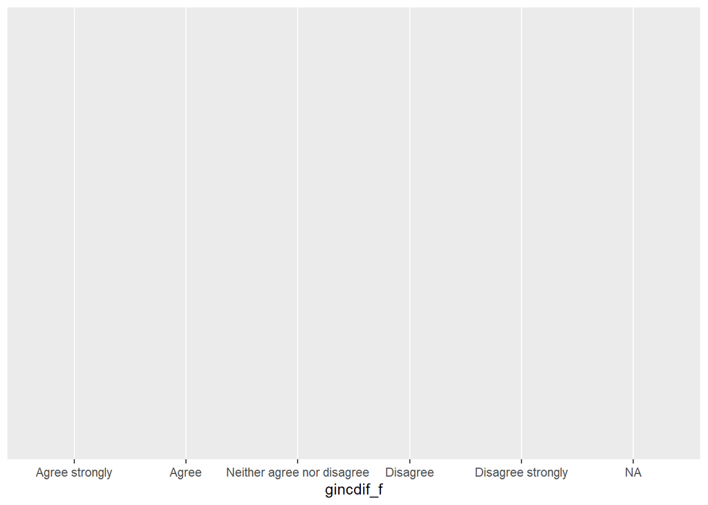

```r
library(ggplot2)
ggplot(data = ee9, mapping = aes(x = gincdif_f, weight = pspwght))
```

Sellest siiski ei piisa, sest peame defineerima ka, et soovime tulpdiagrammi. Selleks lisame koodirea lõppu `+` ja järgmisele reale lisame funktsiooni `geom_bar` (erinevat tüüpi jooniste ehk täpsemalt visuaalsete elementide jaoks on erinevad `geom_`id, nt hajuvusdiagrammi saame funktsiooniga `geom_point`, joondiagrammi funktsiooniga `geom_line`).

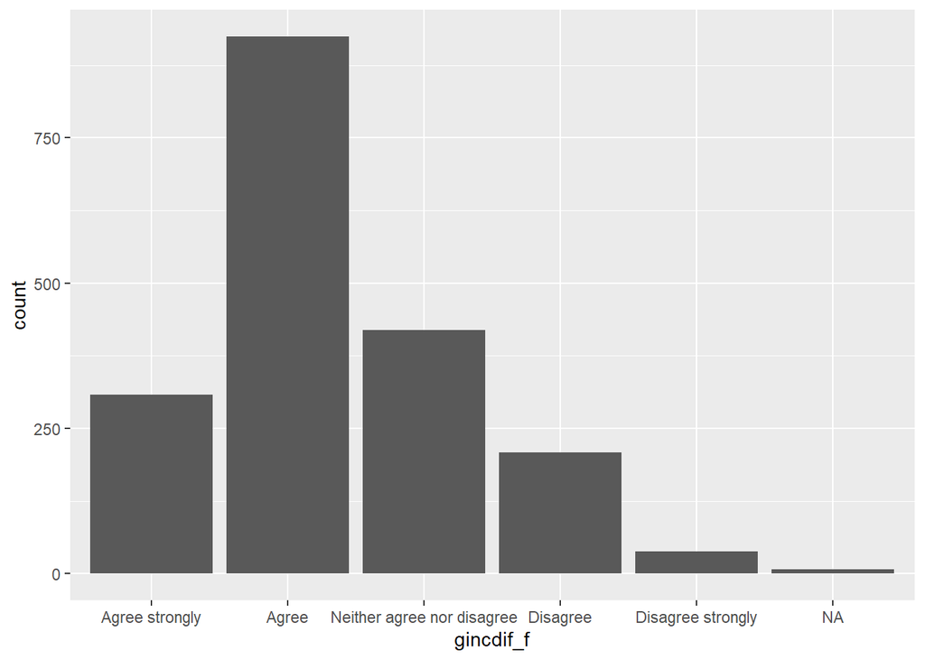

```r
ggplot(data = ee9, mapping = aes(x = gincdif_f, weight = pspwght)) +
  geom_bar()
```

Kui soovime andmelünkade sagedust joonisel mitte näidata, saame andmelüngad eelnevalt lihtsalt välja filtreerida:

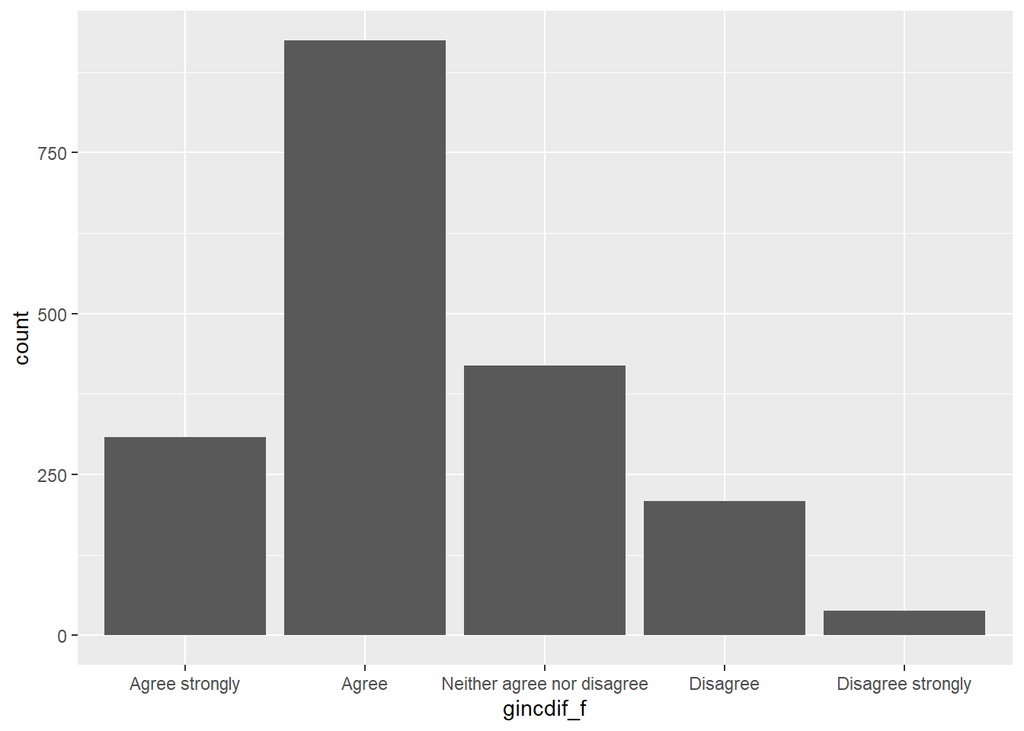

```r
library(tidyr) # kui R ütleb, et ei leia funktsiooni drop_na, siis võib selle paketi sisse laadida

ee9 %>%
  drop_na(gincdif_f) %>%
  ggplot(mapping = aes(x = gincdif_f, weight = pspwght)) +
    geom_bar()
```

Kui soovime y-teljel mitte indiviidide arvu, vaid protsente, siis tuleb täpsustada funktsiooni `aes` argumendi `y` väärtus `stat(prop)` - funktsiooniga `stat` esitatakse joonise aluseks olevad andmed mingi statistilise teisenduse alusel, `prop` määrabki ära, et soovime indiviidide arvud teisendada osakaaludeks. Argument `group = 1` tuleb lisada, et defineerida, et osakaale ei arvutata mingite gruppide lõikes, vaid kõigi viie kategooria osakaalud annavad kokku 1 ehk 100%.

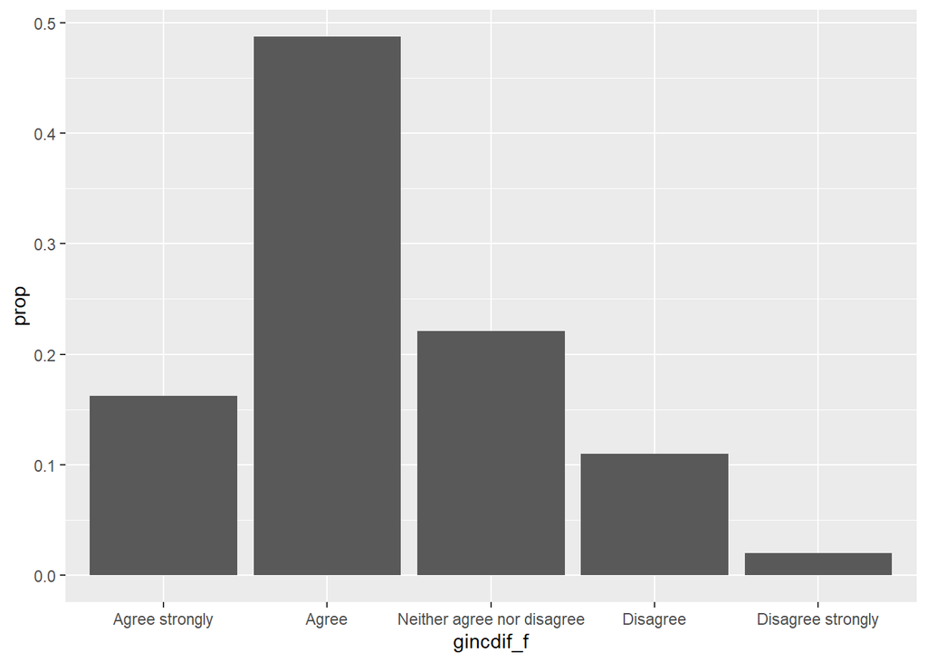

```r
ee9 %>%
  drop_na(gincdif_f) %>%
  ggplot(mapping = aes(x = gincdif_f, y = stat(prop), group = 1, weight = pspwght)) +
    geom_bar()
```

Lisame ka joonisele pealkirja ja telgede nimed (kuigi tunnuse kategooriad on joonisel ingliskeelsed, lisan muu info eestikeelsena; korrektseks esitamiseks peaks muidugi kogu info olema ühes keeles):

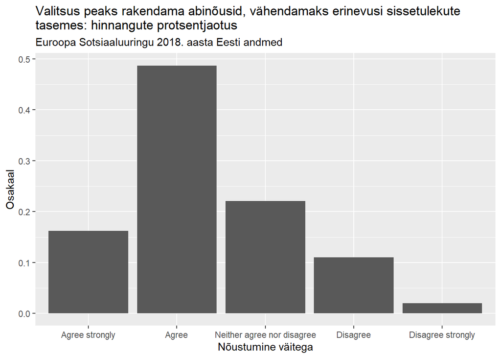

```r
ee9 %>%
  drop_na(gincdif_f) %>%
  ggplot(mapping = aes(x = gincdif_f, y = stat(prop), group = 1, weight = pspwght)) +
    geom_bar() +
    labs(title = "Valitsus peaks rakendama abinõusid, vähendamaks erinevusi sissetulekute \ntasemes: hinnangute protsentjaotus",
         subtitle = "Euroopa Sotsiaaluuringu 2018. aasta Eesti andmed",
         x = "Nõustumine väitega",
         y = "Osakaal")
```

Kui soovime protsentjaotusi grupiti, nt soo lõikes, siis tuleb defineerida `group = gndr_f` ning et eristus soo alusel ka nähtav oleks, siis `fill = gndr_f`.

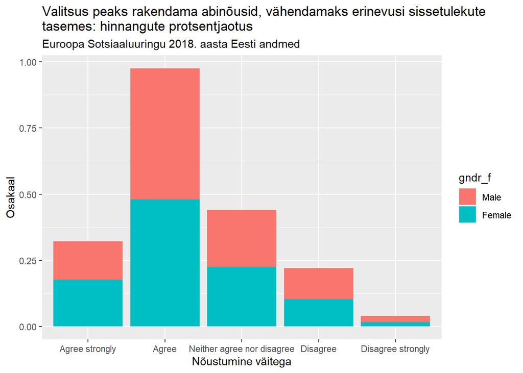

```r
ggplot(ee9 %>% drop_na(gincdif_f), aes(x = gincdif_f, y = stat(prop), group = gndr_f, fill = gndr_f, weight = pspwght)) +
  geom_bar() +
    labs(title = "Valitsus peaks rakendama abinõusid, vähendamaks erinevusi sissetulekute \ntasemes: hinnangute protsentjaotus",
         subtitle = "Euroopa Sotsiaaluuringu 2018. aasta Eesti andmed",
         x = "Nõustumine väitega",
         y = "Osakaal")
```

Meeste ja naiste tulpade teineteise otsa asetamine ei anna siiski head tulemust, sest protsendid on arvutatud soo lõikes, st meeste ja naiste kohta eraldi. Nii ei anna näiteks joonisel olev info, et väitega nõustuvate meeste ja naiste protsentide summa on ligi 100%, meile mingit sisulist infot. Asetame meeste ja naiste tulbad kõrvuti, lisades argumendi `position = "dodge"`.

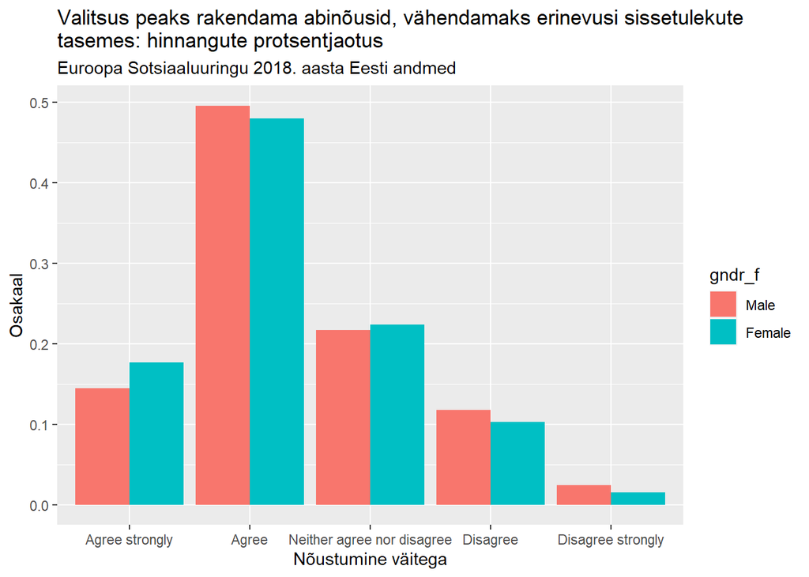

```r
ggplot(ee9 %>% drop_na(gincdif_f), aes(x = gincdif_f, y = stat(prop), group = gndr_f, fill = gndr_f, weight = pspwght)) +
  geom_bar(position = "dodge") +
    labs(title = "Valitsus peaks rakendama abinõusid, vähendamaks erinevusi sissetulekute \ntasemes: hinnangute protsentjaotus",
         subtitle = "Euroopa Sotsiaaluuringu 2018. aasta Eesti andmed",
         x = "Nõustumine väitega",
         y = "Osakaal")
```